# PyData London Oct 2026

### 110th Meetup, hosted by Birkbeck, University of London

### [@pydatalondon.bsky.social](https://bsky.app/profile/pydatalondon.bsky.social)

## PyData Code of Conduct

### Be thoughtful. Be kind to each other.

**https://pydata.org/code-of-conduct/**

[interactive chart not shown]

## PyData

- Educational program of **NumFOCUS** — the charity behind NumPy, pandas, Jupyter and friends
- A global community: **121 groups across 51 countries** on Meetup (plus more off-platform)
- **209,000+ members** worldwide
- https://www.meetup.com/pro/pydata/ · https://numfocus.org

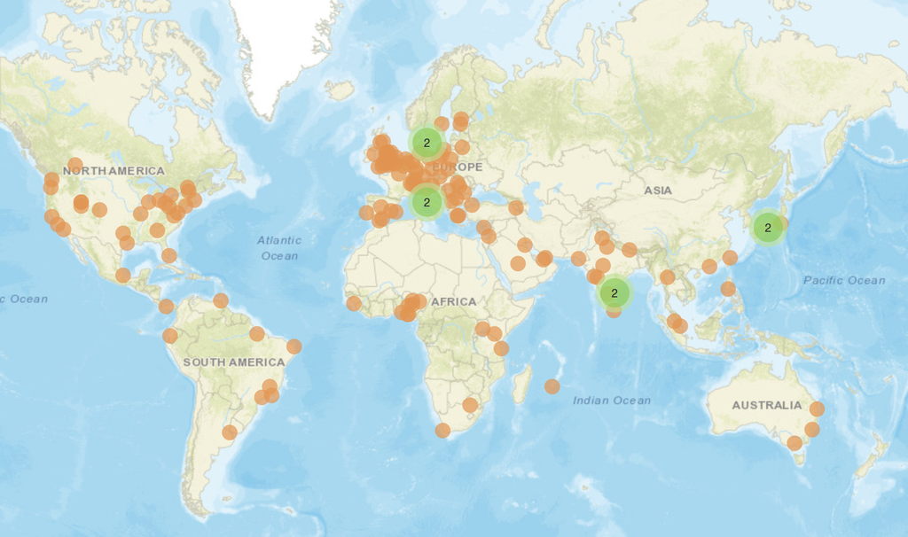

## PyData Meetups in UK

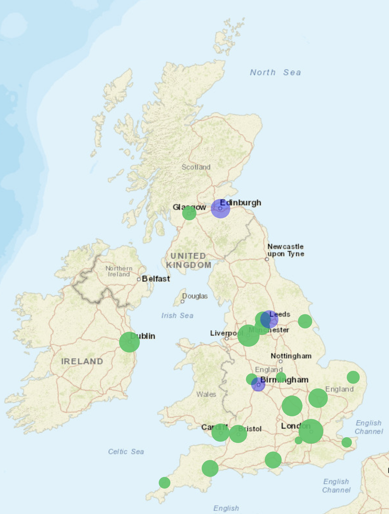

## PyData London

- **16,456 members** and growing — monthly meetup + annual conference
- All run by volunteers
- Propose a talk: https://london.pydata.org/submit-a-talk/

[figure not shown]

## Thank our sponsors - Birkbeck, University of London and MAN Group

[figure not shown]

- Build your data science and AI skills with an **MSc in Data Science**
- Full-time and part-time study options available
- Proud supporters of **PyData London** ❤️❤️❤️
- The world's largest publicly traded hedge fund company
- Lots of open positions in both tech and research!
- Sponsors **PyData London** ❤️❤️❤️

- **Wed 7 Oct** — PyData Bristol *(Social)*
- **Mon 12 Oct** — PyData Milton Keynes *(Sovereign AI: Building AI You Can Trust)*
- **Tue 13 Oct** — PyData Manchester *(PyDataMCR October @ Data Decoded MCR)*

## Upcoming Conferences

### Courtesy of https://pythondeadlin.es/

[interactive chart not shown]

## Since We Last Met -- wider Python community updates

### 🌍 PyData Global 2026

**8–10 December · Online**  
Three days of talks, keynotes and community learning.

### 🎥 PyCon US 2026 recordings

**All recordings now available on YouTube**  
Catch up on talks and share your favourites.

### 🚀 Python 3.15 is almost here

**Final release scheduled for 9 October**  
Lazy imports for faster startup + a new built-in sampling profiler.

### 🔄 Python 3.10 reached end of life

**No further security updates from 1 October**  
Time to upgrade your notebooks, pipelines and deployments.

## Tonight's Schedule

- **18:30** Doors open
- **19:00** Introduction <- **YOU ARE HERE**
- **19:15** Main Talk & Q&A -> *From PoC to Production: Building Scalable Agentic Applications* - **Sultan Al Awar** and **Ksenia Shishkanova**
- **19:45** Community Announcement + Break + Networking
- **20:00** Main Talk & Q&A -> *Listening to black holes with missing data* - **Kavit Tolia**
- **20:30** ⚡️Lightning Talk #1 -> *Making Python Faster* - **Richard Hickling**
- **20:40** We're done -> Continue Conversation in the Pub🍺